# Download Data from the Statistic Canada

## Step 1: Open data

1. Access the full customization table of the dataset.
2. Below the “Customize table” option, click on “Add/Remove data” if you need to adjust the dataset.

[figure not shown]

step1

## Step 2: Set the reference period

1. After selecting the desired data, navigate to the “Reference period” tab.
2. Set the “from” date to “2019” and the “to” date to “2023”.

[figure not shown]

Step2

## Step 3: Apply the changes

Click the “Apply” button at the bottom of the customization window to confirm your selections.

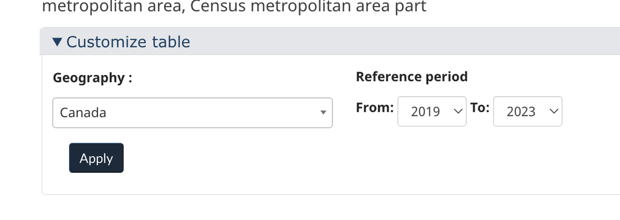

Step3

## Step 4: Download the dataset

1. Double-check that the data displayed reflects your changes.
2. Click the “Download options” button above the displayed data.
3. In the pop-up window, select “CSV Download selected data” for downloading.

Click the “Download options” button above the data and below the “Customize table” window. This will open a pop-up window, shown below, with various download options.

Select “CSV Download selected data”.

[figure not shown]

Step 4

## Step 5: Preview CSV file

After downloading, preview the CSV file in your preferred editor to ensure it matches your requirements. Repeat the download process if necessary.

[figure not shown]

Step 5

## Step 6: Move file into repository

Once the dataset is confirmed to be correct, move it into the `data/raw_data` folder in your repository for further processing or analysis.